# Naïve Bayes in R with Labeled Record Data

### Introduction

In this page, I will demonstrate how I apply Naïve Bayes model(s) to labeled record using R, as well as the result of the predictions using the trained NB model(s).

### Data Source and Preparation

The data I will be using in this part was the record data (FertilityRate_Clean.csv) cleaned and labeled in the previous data cleaning section, which can be found [here](https://github.com/anly501/anly-501-project-yeyaxin1103/tree/main/data/01-modified-data). The code for data cleaning and labeling can be found [here](https://github.com/anly501/anly-501-project-yeyaxin1103/tree/main/codes/02-data-cleaning). The general information of this data set will be displayed below, and each record is labeled as either “Above Replacement” or “Below Replacement” based on its “FertilityRate” column value.

```r
# read csv file to DataFrame
df <- read.csv("../../data/01-modified-data/FertilityRate_Clean.csv")
str(df)
```

```
## 'data.frame':    5735 obs. of  10 variables:
##  $ Country_Name               : chr  "Afghanistan" "Afghanistan" "Afghanistan" "Afghanistan" ...
##  $ Country_Code               : chr  "AFG" "AFG" "AFG" "AFG" ...
##  $ year                       : int  1990 1991 1992 1993 1994 1995 1996 1997 1998 1999 ...
##  $ FertilityRate              : num  7.47 7.48 7.5 7.54 7.57 ...
##  $ Region                     : chr  "South Asia" "South Asia" "South Asia" "South Asia" ...
##  $ IncomeGroup                : chr  "Low income" "Low income" "Low income" "Low income" ...
##  $ GDPperCapita_USD           : num  287 287 287 287 287 ...
##  $ Human_Dev_Index            : num  0.427 0.427 0.427 0.427 0.427 ...
##  $ Tertiary_school_Enroll_Pctg: num  2.21 2.78 2.78 2.78 2.78 ...
##  $ label                      : chr  "Above Replacement" "Above Replacement" "Above Replacement" "Above Replacement" ...
```

Select the features needed for model training, in this case we only need columns “GDPperCapita_USD”, “Human_Dev_Index”, “Tertiary_school_Enroll_Pctg”, “Region” as input X and column “label” as output y. Also to rename the factor levels of column “Region” (“East Asia & Pacific” as 1, “Europe & Central Asia” as 2, “Latin America & Caribbean” as 3, “Middle East & North Africa” as 4, “North America” as 5, “South Asia” as 6, “Sub-Saharan Africa” as 7).

```r
df$label <- as.factor(df$label)
df$Region <- as.factor(df$Region)
levels(df$Region) <- c(1, 2, 3, 4, 5, 6, 7)
df <- df[, c("label", "GDPperCapita_USD", "Human_Dev_Index", "Tertiary_school_Enroll_Pctg", "Region")]
str(df)
```

```
## 'data.frame':    5735 obs. of  5 variables:
##  $ label                      : Factor w/ 2 levels "Above Replacement",..: 1 1 1 1 1 1 1 1 1 1 ...
##  $ GDPperCapita_USD           : num  287 287 287 287 287 ...
##  $ Human_Dev_Index            : num  0.427 0.427 0.427 0.427 0.427 ...
##  $ Tertiary_school_Enroll_Pctg: num  2.21 2.78 2.78 2.78 2.78 ...
##  $ Region                     : Factor w/ 7 levels "1","2","3","4",..: 6 6 6 6 6 6 6 6 6 6 ...
```

Load Relevant Packages

```r
library(naivebayes)
library(dplyr)
library(ggplot2)
library(psych)
```

### Data Normalization

```r
# Normalize numeric data
df$GDPperCapita_USD <- (df$GDPperCapita_USD - mean(df$GDPperCapita_USD)) / sd(df$GDPperCapita_USD)
df$Human_Dev_Index <- (df$Human_Dev_Index - mean(df$Human_Dev_Index)) / sd(df$Human_Dev_Index)
df$Tertiary_school_Enroll_Pctg <- (df$Tertiary_school_Enroll_Pctg - mean(df$Tertiary_school_Enroll_Pctg)) / sd(df$Tertiary_school_Enroll_Pctg)
head(df)
```

```
##               label GDPperCapita_USD Human_Dev_Index
## 1 Above Replacement       -0.5812077       -1.371903
## 2 Above Replacement       -0.5812077       -1.371903
## 3 Above Replacement       -0.5812077       -1.371903
## 4 Above Replacement       -0.5812077       -1.371903
## 5 Above Replacement       -0.5812077       -1.371903
## 6 Above Replacement       -0.5812077       -1.371903
##   Tertiary_school_Enroll_Pctg Region
## 1                  -1.0162058      6
## 2                  -0.9926003      6
## 3                  -0.9926003      6
## 4                  -0.9926003      6
## 5                  -0.9926003      6
## 6                  -0.9926003      6
```

### Data Exploration & Visualization

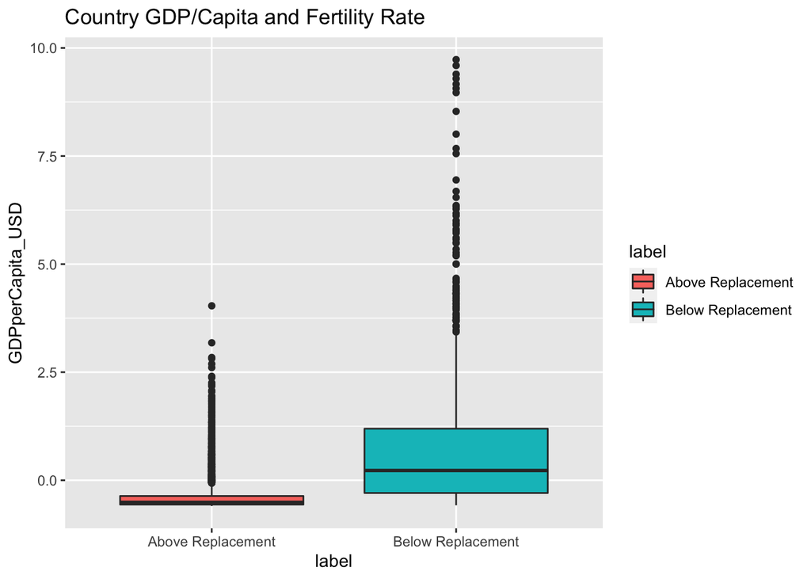

```r
df %>% ggplot(aes(x = label, y = GDPperCapita_USD, fill = label)) +
  geom_boxplot() + ggtitle("Country GDP/Capita and Fertility Rate")
```

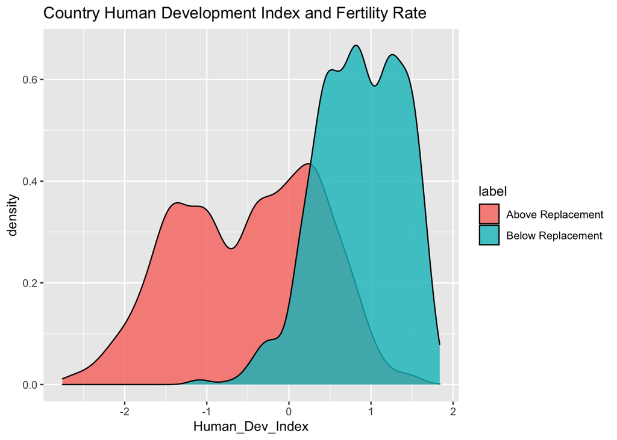

```r
df %>% ggplot(aes(x = Human_Dev_Index, fill = label)) +
  geom_density(alpha = 0.8, color = "black") + ggtitle("Country Human Development Index and Fertility Rate")
```

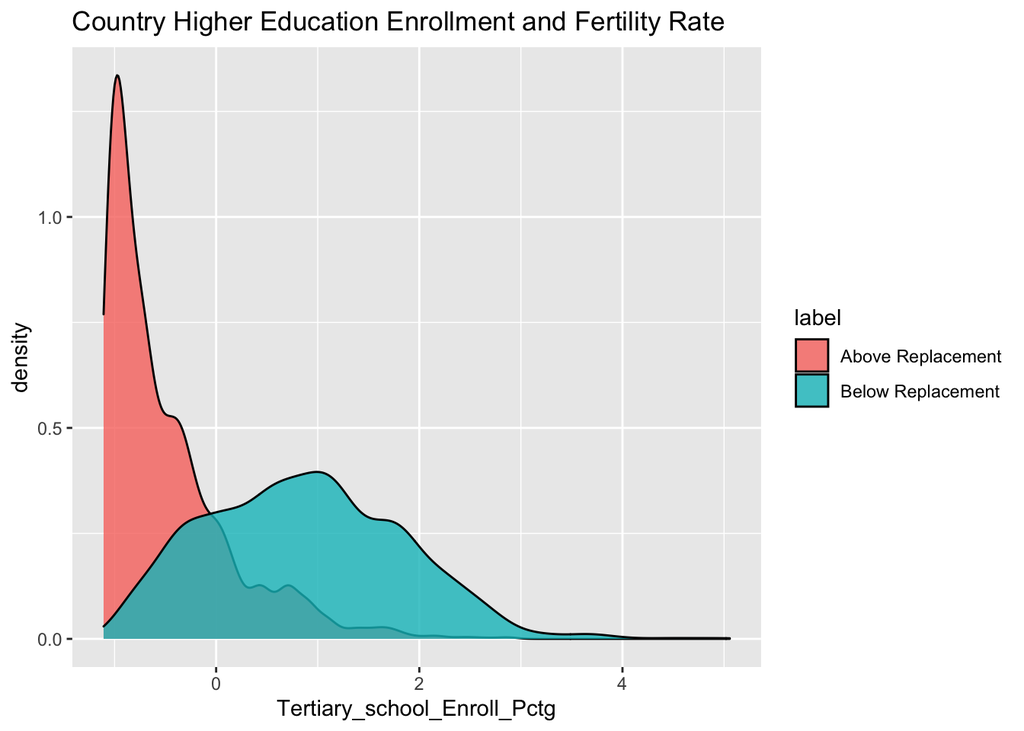

```r
df %>% ggplot(aes(x = Tertiary_school_Enroll_Pctg, fill = label)) +
  geom_density(alpha = 0.8, color = "black") + ggtitle("Country Higher Education Enrollment and Fertility Rate")
```

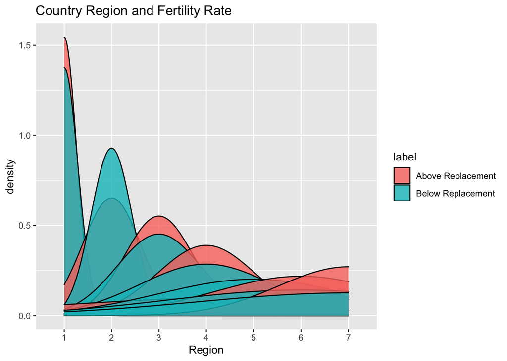

```r
df %>% ggplot(aes(x = Region, fill = label)) +
  geom_density(alpha = 0.8, color = "black") + ggtitle("Country Region and Fertility Rate")
```

The plots show there is potential to develop a classification model.

### Data Partition using 80/20 Rule

```r
set.seed(123)
ind <- sample(2, nrow(df), replace = T, prob = c(0.8, 0.2))
train <- df[ind == 1,]
test <- df[ind == 2,]
```

### Naive Bayes Model

```r
nb <- naive_bayes(label ~ ., data = train)
nb
```

```
##
## ================================== Naive Bayes ==================================
##
##  Call:
## naive_bayes.formula(formula = label ~ ., data = train)
##
## ---------------------------------------------------------------------------------
##
## Laplace smoothing: 0
##
## ---------------------------------------------------------------------------------
##
##  A priori probabilities:
##
## Above Replacement Below Replacement
##         0.6426087         0.3573913
##
## ---------------------------------------------------------------------------------
##
##  Tables:
##
## ---------------------------------------------------------------------------------
##  ::: GDPperCapita_USD (Gaussian)
## ---------------------------------------------------------------------------------
##
## GDPperCapita_USD Above Replacement Below Replacement
##             mean        -0.3859918         0.6623109
##             sd           0.3542397         1.3430315
##
## ---------------------------------------------------------------------------------
##  ::: Human_Dev_Index (Gaussian)
## ---------------------------------------------------------------------------------
##
## Human_Dev_Index Above Replacement Below Replacement
##            mean        -0.5038257         0.8594833
##            sd           0.8713326         0.5167567
##
## ---------------------------------------------------------------------------------
##  ::: Tertiary_school_Enroll_Pctg (Gaussian)
## ---------------------------------------------------------------------------------
##
## Tertiary_school_Enroll_Pctg Above Replacement Below Replacement
##                        mean        -0.4977025         0.8692224
##                        sd           0.6115055         0.9453996
##
## ---------------------------------------------------------------------------------
##  ::: Region (Categorical)
## ---------------------------------------------------------------------------------
##
## Region Above Replacement Below Replacement
##      1       0.140392422       0.134428224
##      2       0.060893099       0.627737226
##      3       0.191813261       0.125304136
##      4       0.150202977       0.055961071
##      5       0.000338295       0.032238443
##      6       0.060893099       0.010948905
##      7       0.395466847       0.013381995
##
## ---------------------------------------------------------------------------------
```

The Naive Bayes model information above show that in the training data, there are about 64.3% of the data points belonging to above replacement category, and about 35.7% belonging to below replacement category. For each quantitative variable in the data set (*Human_Dev_Index*, *GDPperCapita_USD*, *Tertiary_school_Enroll_Pctg* in this case), the mean and standard deviation are calculated. For the categorical variable *Region*, the probabilities are given.

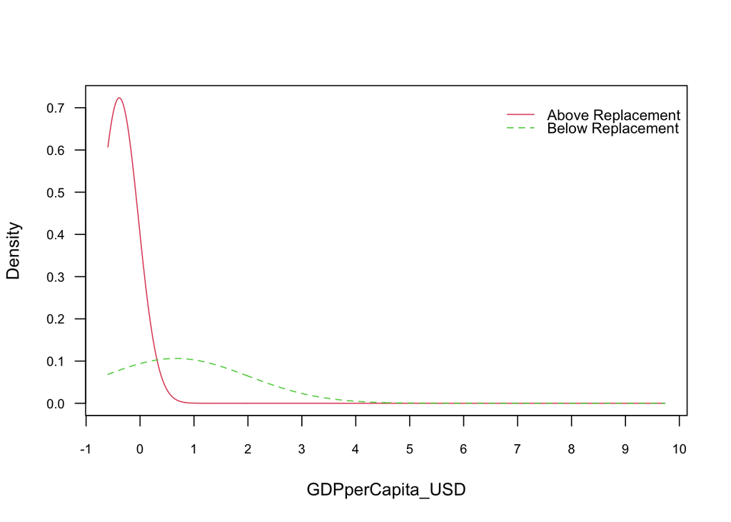

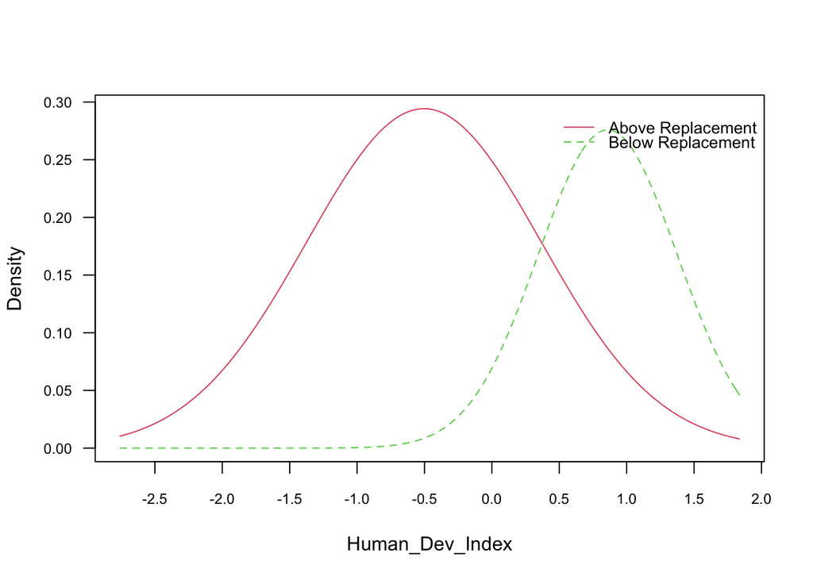

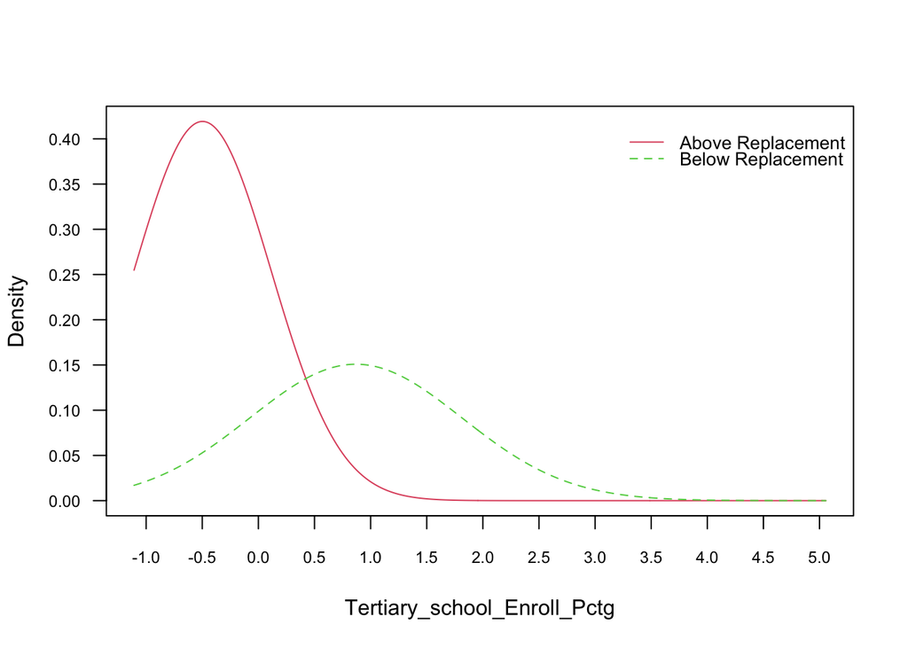

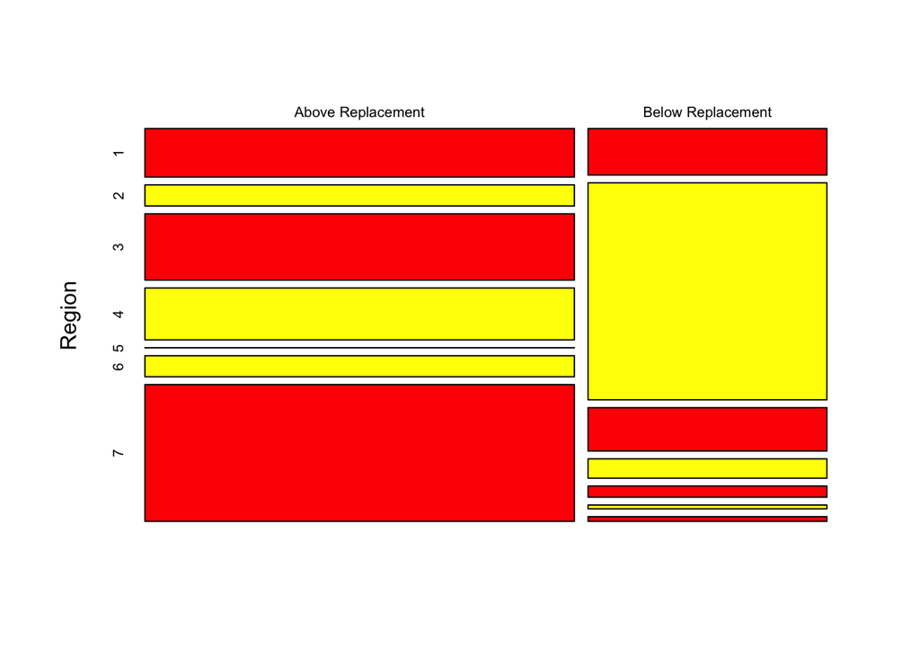

```r
plot(nb)
```

By plotting the NB model, we see that the first three density plots look similar to the ones generated previously. Plot 4 illustrates the chances of countries from a specific region having a below/above replacement fertility rate.

### Model Prediction & Confusion Matrix

#### Predicting Training Data

```r
train_pred <- predict(nb, train)
(tab1 <- table(train_pred, train$label))
```

```
##
## train_pred          Above Replacement Below Replacement
##   Above Replacement              2676               317
##   Below Replacement               280              1327
```

```r
# mis-classification rate
1 - sum(diag(tab1)) / sum(tab1)
```

```
## [1] 0.1297826
```

Based on the confusion matrix and misclassification rate generated above, we can see that 4003 (2676 + 1327) out of 4600 records in the training dataset were predicted correctly, and the misclassification rate of the model is about 12.98%.

#### Predicting Testing Data

```r
test_pred <- predict(nb, test)
(tab2 <- table(test_pred, test$label))
```

```
##
## test_pred           Above Replacement Below Replacement
##   Above Replacement               632                81
##   Below Replacement                64               358
```

```r
# mis-classification rate
1 - sum(diag(tab2)) / sum(tab2)
```

```
## [1] 0.1277533
```

Based on the confusion matrix and misclassification rate generated above, we can see that 990 (632 + 358) out of 1135 records in the testing dataset were predicted correctly, and the misclassification rate of the model is about 12.78%.

Therefore, it can be concluded that this trained Naive Bayes model did a okay job on prediction with about 87% accuracy rate on both training and testing data.